# Module R: Repetition

Author

N. V. Schenk

# Repetition of Module 1

This document is the collection of exercises you have submitted while solving Module 1.

## Checkpoint 1.1

**Exercise**

Now create a new and much longer sequence of numbers from 111 to 222 by 0.02 steps. Save in a vector called c. Now substract the previous vector a from c. What do you observe? Can you explain?

```r
a <- seq(from = 1, to = 5, by = 1)
```

**Solution**

```r
c <- seq(from = 111, to = 222, by = 0.02)
c - a
```

```
Warning in c - a: longer object length is not a multiple of shorter object
length
```

```
   [1] 110.00 109.02 108.04 107.06 106.08 110.10 109.12 108.14 107.16 106.18
  [11] 110.20 109.22 108.24 107.26 106.28 110.30 109.32 108.34 107.36 106.38
  [21] 110.40 109.42 108.44 107.46 106.48 110.50 109.52 108.54 107.56 106.58
  [31] 110.60 109.62 108.64 107.66 106.68 110.70 109.72 108.74 107.76 106.78
  [41] 110.80 109.82 108.84 107.86 106.88 110.90 109.92 108.94 107.96 106.98
  [51] 111.00 110.02 109.04 108.06 107.08 111.10 110.12 109.14 108.16 107.18
  [61] 111.20 110.22 109.24 108.26 107.28 111.30 110.32 109.34 108.36 107.38
  [71] 111.40 110.42 109.44 108.46 107.48 111.50 110.52 109.54 108.56 107.58
  [81] 111.60 110.62 109.64 108.66 107.68 111.70 110.72 109.74 108.76 107.78
  [91] 111.80 110.82 109.84 108.86 107.88 111.90 110.92 109.94 108.96 107.98
 [101] 112.00 111.02 110.04 109.06 108.08 112.10 111.12 110.14 109.16 108.18
 [111] 112.20 111.22 110.24 109.26 108.28 112.30 111.32 110.34 109.36 108.38
 [121] 112.40 111.42 110.44 109.46 108.48 112.50 111.52 110.54 109.56 108.58
 [131] 112.60 111.62 110.64 109.66 108.68 112.70 111.72 110.74 109.76 108.78
 [141] 112.80 111.82 110.84 109.86 108.88 112.90 111.92 110.94 109.96 108.98
```

[output cut: 541 more lines]

```r
getOption("max.print")
```

```
[1] 99999
```

**Exercise**

Create a vector `x` which is a sequence from 10 to 90 step size 5. Create another vector `y` from 100 to 900 with step size 50. Add those two vectors.

**Solution**

```r
x<- seq(from = 10, to = 90, by = 5)
y<- seq(from = 100, to = 900, by = 50)
x+y
```

```
 [1] 110 165 220 275 330 385 440 495 550 605 660 715 770 825 880 935 990
```

**Exercise**

Create a sequence between 40 and a 160 with iterations of 2 and save them as vector 1

**Solution**

```r
vec1=seq(from=40, to=160, by=2)
```

**Exercise**

Create two sequences of numbers. The first from 5 to 15 with iterations of 1. Save this sequence as variable a. The second sequence ranges from 0.5 to 1.5 with steps of 0.1. Save this as variable b. Then add the two variables

**Solution**

```r
a=seq(from=5, to=15, by=1)
b=seq(from=0.5, to=1.5, by=0.1)
a+b
```

```
 [1]  5.5  6.6  7.7  8.8  9.9 11.0 12.1 13.2 14.3 15.4 16.5
```

**Exercise**

Create two sequences of numbers : The first is a sequence of numbers from 1 to 5, with steps of 1. Save this sequence in a variable called a. The second sequence is a sequence of numbers from 0.1 to 0.3, with steps of 0.1. Save this sequence in a variable called b. Subtract a from b.

**Solution**

```r
a<-seq(from = 1, to = 5, by = 1)
b<- seq(from = 0.1, to = 0.3, by = 0.1)
sum_ab<- b-a # R adjusts the length of b according the sequence of a and substracts the values correspondingly from each sequence.
sum_ab
```

```
[1] -0.9 -1.8 -2.7 -3.9 -4.8
```

**Exercise**

Create a sequence `year` of years between 1992 and 2023 and a sequence `month` of months between 1 and 12.

**Solution**

```r
year <- seq(from = 1992,to = 2023,by = 1)
month <- seq(from = 1,to = 12,by = 1)
```

**Exercise**

Create three sequences of numbers : The first is a sequence of numbers from 0 to 5, with steps of 1. Save this sequence in a variable called a. The second sequence is a sequence of numbers from 0 to 2.5, with steps of 0.5. Save this sequence in a variable called b. The third sequence is a sequence of numbers from 0 to 0.5, with steps of 0.1. Save this sequence in a variable called c. Add a the sequences a and b, then divide by sequence c.

**Solution**

```r
a <- seq(from = 0, to = 5, by = 1)
b <- seq(from = 0, to = 2.5, by = 0.5)
c <- seq(from = 0, to = 0.5, by = 0.1)
(a+b)/c
```

```
[1] NaN  15  15  15  15  15
```

Note that the first result is NaN which stands for “Not a number” and indicates division by zero. The first element of c is zero.

**Exercise**

Create two vectors `a` and `b` : a is a sequence from 1 to 240 with sep size 1. `b` is the square of `a`. Plot the relation of those two vectors (1) using R base and (2) using ggplot2.

**Solution**

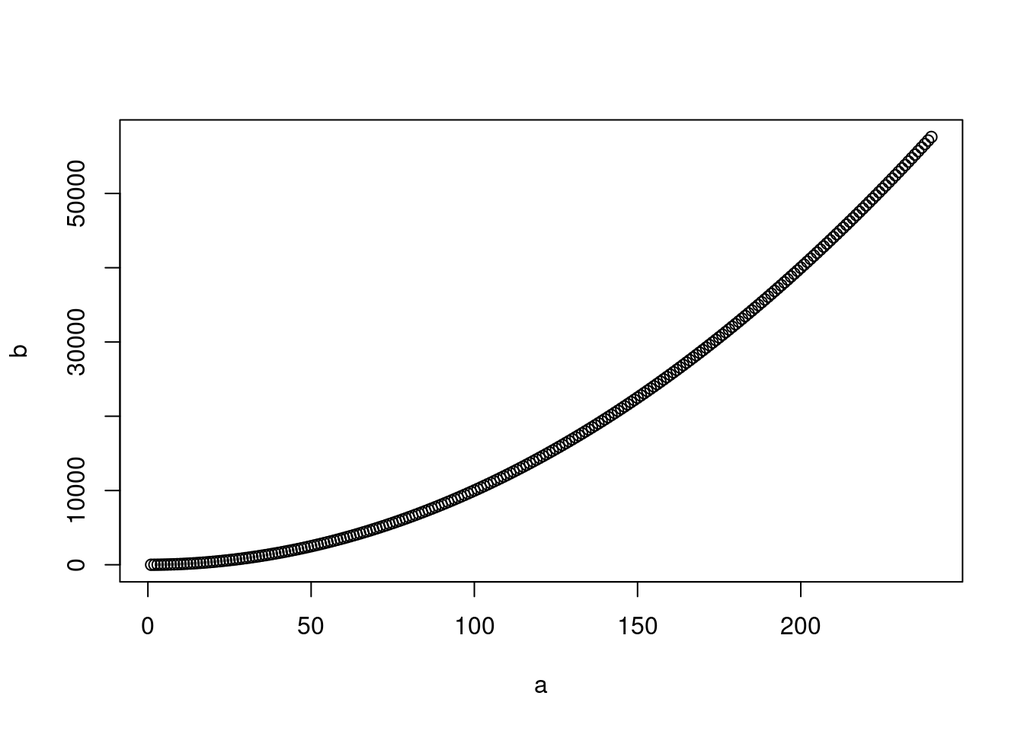

```r
a <- seq(from = 1, to = 240, by = 1)
b <- a^2
plot(a, b)
```

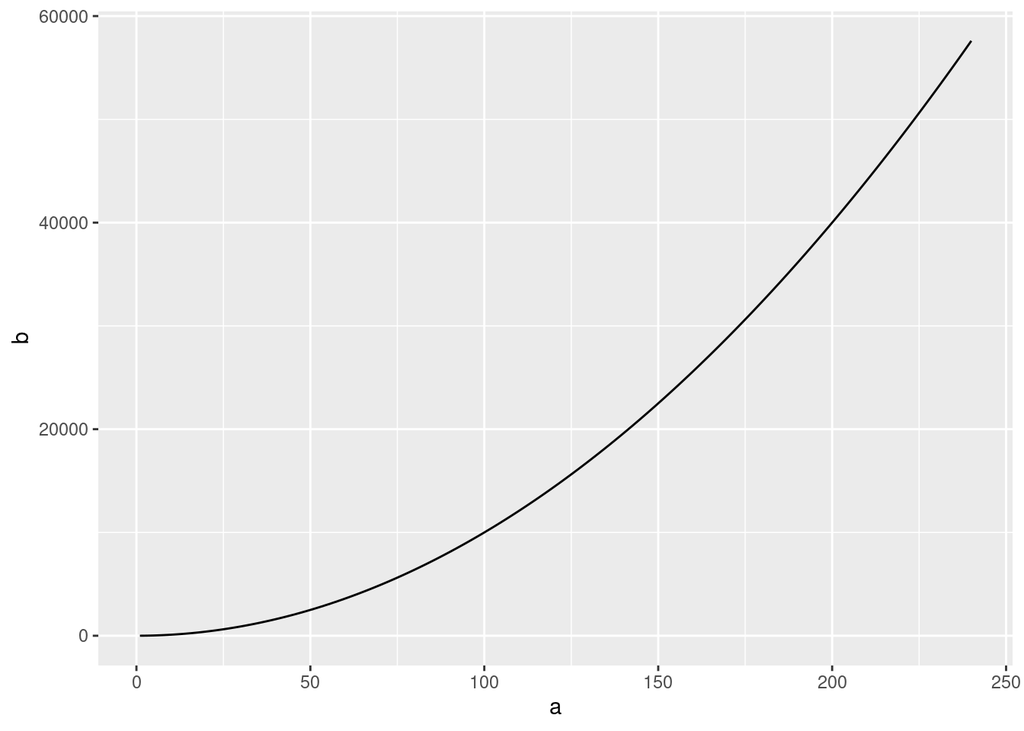

```r
ggplot(data.frame(a, b), aes(x = a, y = b)) +
  geom_line()
```

**Exercise**

The operator `==` (“double-equal”) checks if two elements (e.g. numbers) are the same.

```r
3 == 3 # by returning TRUE, R tells you that 3 is indeed the same as 3
```

```
[1] TRUE
```

```r
3 == 4 # by returning FALSE, R tells you that 3 is NOT the same as 3
```

```
[1] FALSE
```

Create a vector a from 0 to 5 with step size 1. Create a second vector b from 0.1 to 0.3 with step size 0.1. Compare the lengths of vectors a and b, and check if the length is the same, by using the operator `==`

**Solution**

```r
a <- seq(from = 0, to = 5, by = 1)
b <- seq(from = 0.1, to = 0.3, by = 0.1)

# checking the lengths of the two vectors by hand
length(a)
```

```
[1] 6
```

```r
length(b)
```

```
[1] 3
```

```r
# check if the length of vector a is the same as the length of vector b
length(a) == length(b)
```

```
[1] FALSE
```

```r
# their lengths differ, because a is longer than b.
```

**Exercise**

The `>` operator tests if a given element (e.g. a number) is larger than another.

```r
3 > 1 # 3 is larger than 1
```

```
[1] TRUE
```

```r
4 > 5 # 4 is NOT larger than 5
```

```
[1] FALSE
```

Use the operator `>` to check if vector a is longer than vector b.

**Solution**

```r
length(a) > length(b)
```

```
[1] TRUE
```

Vector a is indeed longer than vector b.

**additionally**, you might have tried out this :

```r
a > b
```

```
[1] FALSE  TRUE  TRUE  TRUE  TRUE  TRUE
```

Here, the `>` operator is applied ELEMENTWISE, that means the first element of a is compared to the first element of b. In our case, 0 is compared to 0.1. 0 is not larger than 0.1, therefore the first answer is FALSE. Then, the second element of a is compared to the second element of b, i.e. 1 is compared to 0.2. 1 is larger than 0.2, therefore the second answer is TRUE. And so on.

*note* that again here, the vector b is “recycled”, because it is not as long as a. That means, the fourth element of vector a is compared to the FIRST element of vector b.

**Exercise**

Create two sequences of numbers : The first is a sequence of numbers from 1 to 5, with steps of 1. Save this sequence in a variable called a. The second sequence is a sequence of numbers from 0.1 to 0.3, with steps of 0.1. Save this sequence in a variable called b. Subtract a from b.

**Solution**

```r
a <- seq(from = 1, to = 5, by = 1)
b <- seq(from = 0.1, to = 0.3, by = 0.1)
sum <- b - a # R adjusts the length of b according the sequence of a and subtracts the values correspondingly from each sequence.
sum
```

```
[1] -0.9 -1.8 -2.7 -3.9 -4.8
```

**Exercise**

Create three sequences of numbers : The first is a sequence of numbers from 0 to 5, with steps of 1. Save this sequence in a variable called a. The second sequence is a sequence of numbers from 0 to 2.5, with steps of 0.5. Save this sequence in a variable called b. The third sequence is a sequence of numbers from 0 to 0.5, with steps of 0.1. Save this sequence in a variable called c. Add a the sequences a and b, then divide by sequence c.

**Solution**

```r
a <- seq(from = 0, to = 5, by = 1)
b <- seq(from = 0, to = 2.5, by = 0.5)
c <- seq(from = 0, to = 0.5, by = 0.1)
(a + b) / c
```

```
[1] NaN  15  15  15  15  15
```

*note* that you get a `NaN`, the abbreviation for “not a number”. This is the result of a division through zero, which is not defined. The first element of c is 0.

### Discussion insights

Insights discussed during the individual work or during the discussion sessions.

#### R recycling

In module 1, a shorter vector was recycled to fit the length of a longer vector.

```r
a <- seq(from = 1, to = 5, by = 1)
b <- seq(from = 0.1, to = 0.3, by = 0.1)
a + b
```

```
Warning in a + b: longer object length is not a multiple of shorter object
length
```

```
[1] 1.1 2.2 3.3 4.1 5.2
```

This recycling of vectors is a particularity of R, if you need to search about it’s behaviour, you can refer to it by “R’s recycling rules”.

R’s recycling rules dictate that if the recycled vector fits neatly into the longer vector without partial recycling, no warning is emitted.

That means if vector a was 6 elements long, vector b would fit percetly two times (no splitting of vector b), and you do not get a warning :

```r
a <- seq(from = 1, to = 6, by = 1)
b <- seq(from = 0.1, to = 0.3, by = 0.1)
a + b
```

```
[1] 1.1 2.2 3.3 4.1 5.2 6.3
```

#### overwriting vectors

By re-using a Vector’s name, the former Vector is overwritten

#### Run R code without click

Ctrl + Enter

Run multiple lines at once : select the lines you want to run, Ctrl + Enter

#### Re-starting the graphics device

If plotting does not work any more, sometimes it helps to re-start the graphics device, using :

```r
dev.off()
```

And trying to plot again.